# Basic Usage of the MOEADr Package

Claus Aranha, Felipe Campelo

2023-01-06

We use **MOEADr** to optimize a simple 2-objective problem composed of the Sphere function and the Rastrigin function in $X = \{x_1,x_2,\dots,x_D\} \in\mathbb{R}^D$.

## Setting up the Target Problem:

For this example, we define the sphere and rastrigin function in $\mathbb{R}$ as:
$$\text{sphere}(X) = \sum_{i=1}^D x_i^2\\
\text{rastrigin}(X) = \sum_{i=1}^D (x_i^2 - 10 \text{cos}(2\pi x_i) +
10)$$
Their R implementation is as follows. Because both functions have the optimum at the zero, we apply a simple displacement on the input parameters to make the output of the example problem more interesting.

```r
sphere <- function(X) {
  X.shift <- X + seq_along(X)*0.1     # displace input parameters
  sum(X.shift**2) }
rastringin <- function(X) {
  X.shift <- X - seq_along(X)*0.1     # displace input parameters in the opposite direction
  sum((X.shift)**2 - 10 * cos(2 * pi * X.shift) + 10) }
```

The **MOEADr** package requires the multi objective problem to be defined as a function that receives the entire solution set as a matrix, and return the objective values also as a matrix. For details see the Problem Definition vignette. We will achieve this requirement by wrapping the sphere function and the rastrigin function as follows:

```r
problem.sr <- function(X) {
  t(apply(X, MARGIN = 1,
          FUN = function(X) { c(sphere(X), rastringin(X)) }
   ))
}
```

Finally, we need to create a problem definition list that specifies the number of objectives, and the minimum and maximum parameter values for each dimension:

```r
problem.1 <- list(name       = "problem.sr",  # function that executes the MOP
                  xmin       = rep(-1,30),    # minimum parameter value for each dimension
                  xmax       = rep(1,30),     # maximum parameter value for each dimension
                  m          = 2)             # number of objectives
```

## Setting up **MOEADr**

To load the package and run the problem using the original MOEA/D variant, we use the following commands:

```r
library(MOEADr)
results <- moead(problem  = problem.1,
                 preset   = preset_moead("original"),
                 showpars = list(show.iters = "none"),
                 seed     = 42)
```

The *moead()* function requires a problem definition (discussed in the previous section) and an algorithm configuration (in this case, an algorithm preset, and optional changes to the preset), logging parameters, and a seed. The *preset_moead()* function can output a number of different presets based on combinations found on the literature. In this example, *preset_moead(“original”)* returns the original MOEA/D configuration, as proposed by Zhang and Li (2007)[^1]. You can get a list of available presets by running:

```r
preset_moead()
```

```
#>        name x                                               description
#> 1 original  | Original MOEA/D: Zhang and Li (2007), Sec. V-E, p.721-722
#> 2 original2 | Original MOEA/D, v2: Zhang and Li (2007), Sec. V-F, p.724
#> 3 moead.de  | MOEA/D-DE: Li and Zhang (2009)
#>
#>
#> Use preset_moead("name") to generate a standard MOEAD composition
```

## Visualizing the results

The *moead()* function returns a list object of class *moead*, containing the final solution set, objective values for each solution, and other information about the optimization process. The **MOEADr** package uses S3 to implement versions of *plot()* and *summary()* for this object.

*plot()* will show the pareto front for the objectives, as in the figure below. When the number of objectives is greater than 2, a parallel coordinates plot is also produced (see the next example). *summary()* displays information about the number of non-dominated and feasible solution points, the estimated ideal and nadir values (when available), and (optionally) the IDR and hypervolume yielded by the feasible, nondominated set.

```r
summary(results)
```

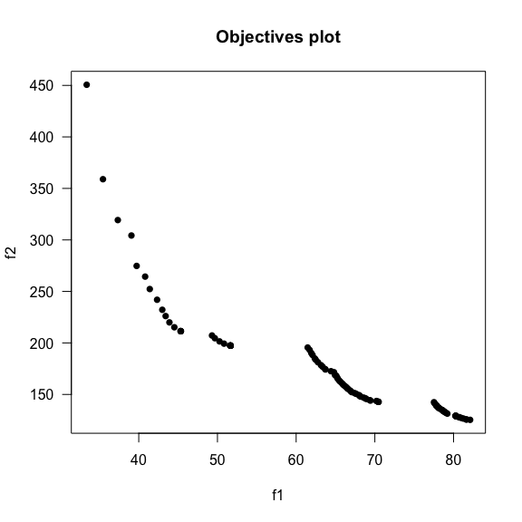

```r
plot(results, suppress.pause = TRUE)
```

## A more complex example

The **smoof** package[^2] provides generators for a large number of single and multi objective test functions. The **MOEADr** package provides a wrapper (function *make_vectorized_smoof()*) to easily convert **smoof** functions to the format required by the *moead()* function. The code snipped below generates a MOP with five objective functions from **smoof**, and the necessary problem definition for *moead()*.

```r
library(smoof)
DTLZ2 <- make_vectorized_smoof(prob.name  = "DTLZ2",
                               dimensions = 20,
                               n.objectives = 5)
problem.dtlz2  <- list(name       = "DTLZ2",
                       xmin       = rep(0, 20),
                       xmax       = rep(1, 20),
                       m          = 5)
```

In this example we will also show how to modify an algorithm preset. Because of the higher number of objectives, we want to reduce the value of the parameter $H$ in the decomposition component *SLD* used by the preset from 100 to 8:

```r
results.dtlz <- moead(problem = problem.dtlz2,
                preset = preset_moead("original"),
                decomp = list(name = "SLD", H = 8),
                showpars = list(show.iters = "dots"),
                seed = 42)
```

```
#>
#> MOEA/D running: ....................
```

Notice on the figure below that **MOEADr** plots extra information when the number of objectives in a problem is greater than 2:

```r
summary(results.dtlz)
```

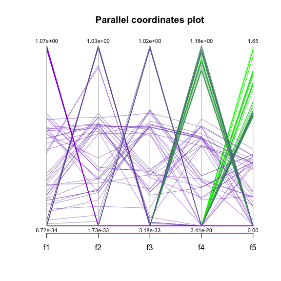

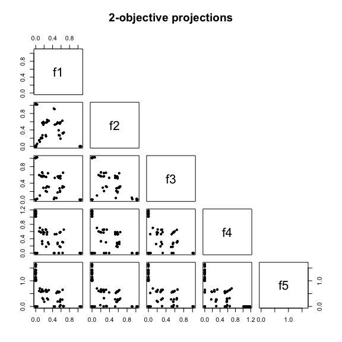

```r
plot(results.dtlz, suppress.pause = TRUE)
```

Note that for more complex MOPs, the preset values suggested by *preset_moead()* might not be effective. For example, the standard value of 100 for $H$ in the *SLD* component is appropriate for 2 objectives, but exceeds the available memory for $m > 3$. Therefore, we strongly recommend that the user explore the meta-parameter space. The next case study shows one way to perform this task semi-automatically.

[^1]: [IEEE Trans. Evol. Comp. 11(6): 712-731, 2007](https://doi.org/10.1109/TEVC.2007.892759).
[^2]: https://CRAN.R-project.org/package=smoof